# Assignment 5

Ishika Nisha

11/29/2021

#Reading the directory

```r
getwd()
```

```
## [1] "C:/Users/Nikesh/Downloads"
```

#Reading the file

```r
Assign <-read.csv("Cereals.csv")
```

#Required packages

```r
library(dplyr)
library(cluster)
library(fpc)
library(caret)
library(dendextend)
library(knitr)
library(factoextra)
library(tidytext)
```

#Data in brief

```r
summary(Assign)
```

```
##      name               mfr                type              calories
##  Length:77          Length:77          Length:77          Min.   : 50.0
##  Class :character   Class :character   Class :character   1st Qu.:100.0
##  Mode  :character   Mode  :character   Mode  :character   Median :110.0
##                                                           Mean   :106.9
##                                                           3rd Qu.:110.0
##                                                           Max.   :160.0
##
##     protein           fat            sodium          fiber
##  Min.   :1.000   Min.   :0.000   Min.   :  0.0   Min.   : 0.000
##  1st Qu.:2.000   1st Qu.:0.000   1st Qu.:130.0   1st Qu.: 1.000
##  Median :3.000   Median :1.000   Median :180.0   Median : 2.000
##  Mean   :2.545   Mean   :1.013   Mean   :159.7   Mean   : 2.152
##  3rd Qu.:3.000   3rd Qu.:2.000   3rd Qu.:210.0   3rd Qu.: 3.000
##  Max.   :6.000   Max.   :5.000   Max.   :320.0   Max.   :14.000
##
##      carbo          sugars           potass          vitamins
##  Min.   : 5.0   Min.   : 0.000   Min.   : 15.00   Min.   :  0.00
##  1st Qu.:12.0   1st Qu.: 3.000   1st Qu.: 42.50   1st Qu.: 25.00
##  Median :14.5   Median : 7.000   Median : 90.00   Median : 25.00
##  Mean   :14.8   Mean   : 7.026   Mean   : 98.67   Mean   : 28.25
##  3rd Qu.:17.0   3rd Qu.:11.000   3rd Qu.:120.00   3rd Qu.: 25.00
##  Max.   :23.0   Max.   :15.000   Max.   :330.00   Max.   :100.00
##  NA's   :1      NA's   :1        NA's   :2
##      shelf           weight          cups           rating
##  Min.   :1.000   Min.   :0.50   Min.   :0.250   Min.   :18.04
##  1st Qu.:1.000   1st Qu.:1.00   1st Qu.:0.670   1st Qu.:33.17
##  Median :2.000   Median :1.00   Median :0.750   Median :40.40
##  Mean   :2.208   Mean   :1.03   Mean   :0.821   Mean   :42.67
##  3rd Qu.:3.000   3rd Qu.:1.00   3rd Qu.:1.000   3rd Qu.:50.83
##  Max.   :3.000   Max.   :1.50   Max.   :1.500   Max.   :93.70
##
```

```r
head(Assign)
```

```
##                        name mfr type calories protein fat sodium fiber carbo
## 1                 100%_Bran   N    C       70       4   1    130  10.0   5.0
## 2         100%_Natural_Bran   Q    C      120       3   5     15   2.0   8.0
## 3                  All-Bran   K    C       70       4   1    260   9.0   7.0
## 4 All-Bran_with_Extra_Fiber   K    C       50       4   0    140  14.0   8.0
## 5            Almond_Delight   R    C      110       2   2    200   1.0  14.0
## 6   Apple_Cinnamon_Cheerios   G    C      110       2   2    180   1.5  10.5
##   sugars potass vitamins shelf weight cups   rating
## 1      6    280       25     3      1 0.33 68.40297
## 2      8    135        0     3      1 1.00 33.98368
## 3      5    320       25     3      1 0.33 59.42551
## 4      0    330       25     3      1 0.50 93.70491
## 5      8     NA       25     3      1 0.75 34.38484
## 6     10     70       25     1      1 0.75 29.50954
```

#Eliminating mrf and type from the dataset(character data)

```r
Assign_New <-select(Assign,-c('mfr','type'))
```

#Cheacking the new dataset after eliminating the data

```r
head(Assign_New)
```

```
##                        name calories protein fat sodium fiber carbo sugars
## 1                 100%_Bran       70       4   1    130  10.0   5.0      6
## 2         100%_Natural_Bran      120       3   5     15   2.0   8.0      8
## 3                  All-Bran       70       4   1    260   9.0   7.0      5
## 4 All-Bran_with_Extra_Fiber       50       4   0    140  14.0   8.0      0
## 5            Almond_Delight      110       2   2    200   1.0  14.0      8
## 6   Apple_Cinnamon_Cheerios      110       2   2    180   1.5  10.5     10
##   potass vitamins shelf weight cups   rating
## 1    280       25     3      1 0.33 68.40297
## 2    135        0     3      1 1.00 33.98368
## 3    320       25     3      1 0.33 59.42551
## 4    330       25     3      1 0.50 93.70491
## 5     NA       25     3      1 0.75 34.38484
## 6     70       25     1      1 0.75 29.50954
```

#Eliminating name from dataset and changing row number as name to avoid duplication

```r
rownames(Assign_New)<-Assign_New$name
Assign_New$name=NULL
```

#Normalizing the data

```r
Assign_New<-as.data.frame(scale(Assign_New))
```

#Preprocessing the data

```r
sum(is.na(Assign_New))
```

```
## [1] 4
```

```r
Assign_New<-na.omit(Assign_New)
```

#Calculation of Dissimilarity Matrix and performing Hierarchial Clustering

```r
Dis <- dist(Assign_New, method = "euclidean")
H_clust <- hclust(Dis, method = "complete")
```

#Plotting the dendogram

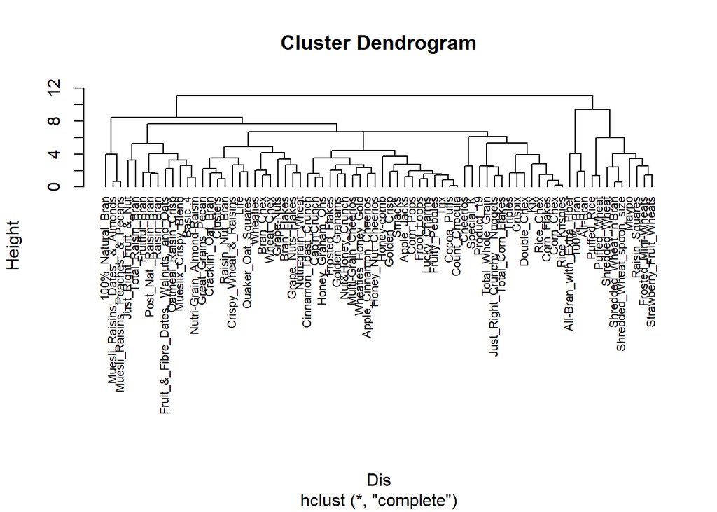

```r
plot(H_clust, cex = 0.7, hang = -1)
```

#Q1. Apply hierarchical clustering to the data using Euclidean distance to the normalized measurements. Use Agnes to compare the clustering from single linkage, complete linkage, average linkage, and Ward. Choose the best method.

#Single linkage: computes the minimum distance between clusters before merging them.

#Complete linkage: computes the maximum distance between clusters before merging them.

#Average linkage: computes the average distance between clusters before merging them.

#Ward’s (minimum variance) criterion: minimizes the total within-cluster variance and find the pair of clusters that leads to minimum increase in total within-cluster variance after merging.

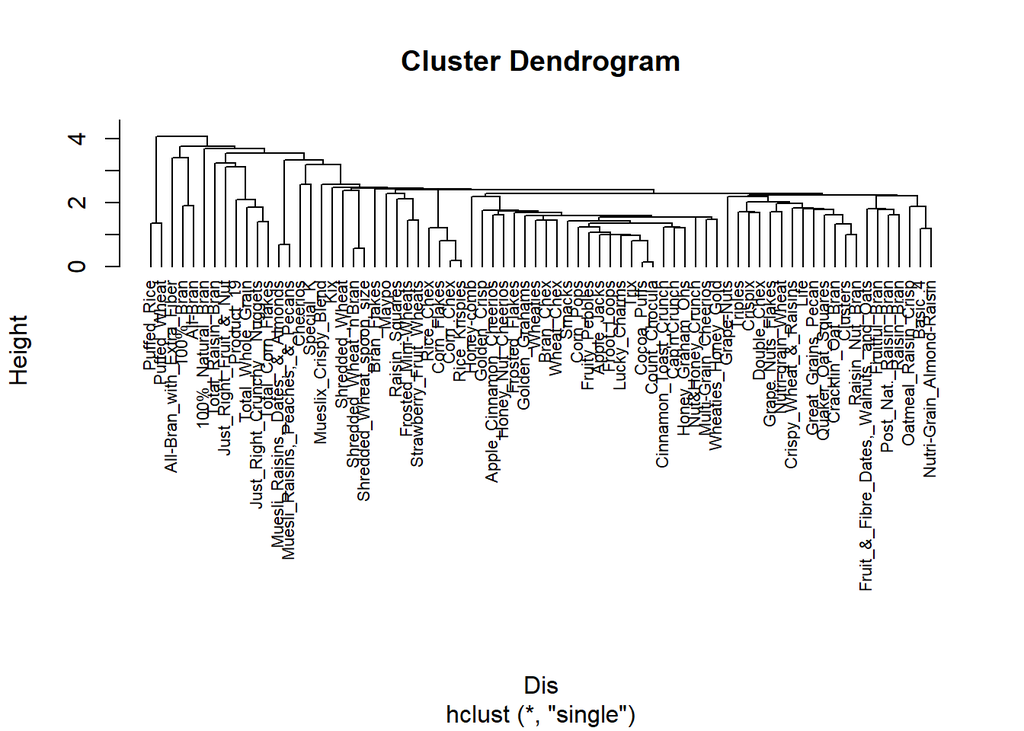

```r
hc_S <- hclust(Dis,method="single")
plot(hc_S,cex=0.7,hang=-1)
```

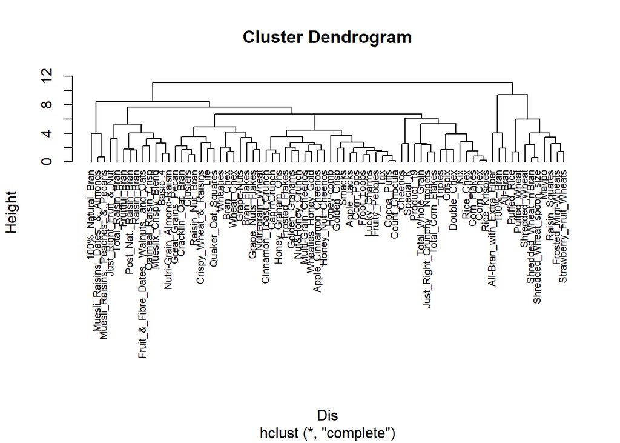

```r
hc_C<- hclust(Dis,method="complete")
plot(hc_C,cex=0.7,hang=-1)
```

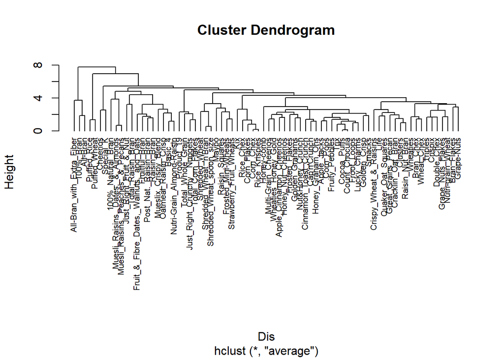

```r
hc_A <- hclust(Dis,method="average")
plot(hc_A,cex=0.7,hang=-1)
```

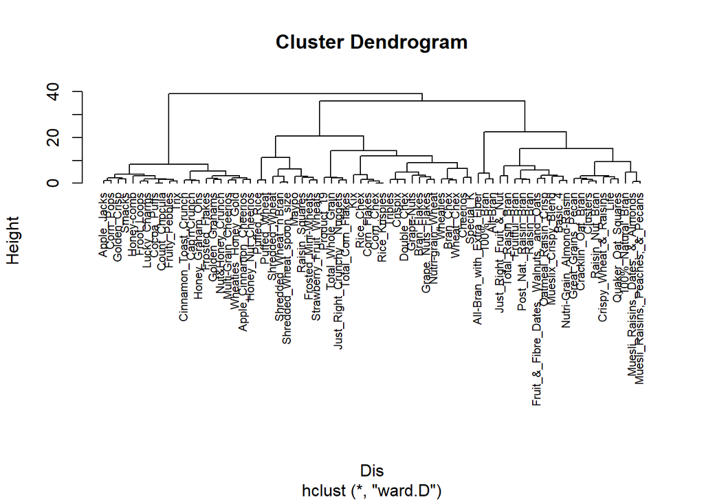

```r
hc_W <- hclust(Dis,method="ward.D")
plot(hc_W,cex=0.7,hang=-1)
```

#Computation with Agnes and Single Linkage vs Complete Linkage vs Average Linkage vs Ward

```r
hc_S <- agnes(Dis,method="single")
print(hc_S$ac)
```

```
## [1] 0.6094447
```

```r
hc_C <- agnes(Dis,method="complete")
print(hc_C$ac)
```

```
## [1] 0.8413498
```

```r
hc_A <- agnes(Dis,method="average")
print(hc_A$ac)
```

```
## [1] 0.7814484
```

```r
hc_W <- agnes(Dis,method="ward")
print(hc_W$ac)
```

```
## [1] 0.9049881
```

#The Best Linkage method is Ward with Agglomerative coefficient of 0.9049881.

#Dendrogram of Ward

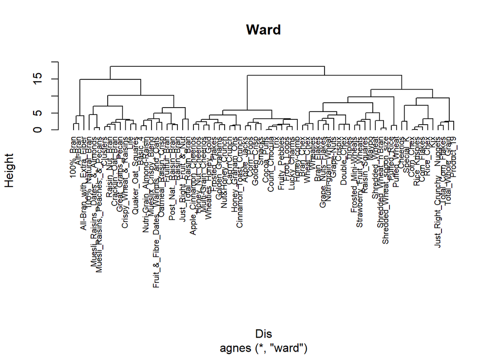

```r
pltree(hc_W,cex=0.7,hang=-1,main="Ward")
```

#Q2 Choosing the number of clusters

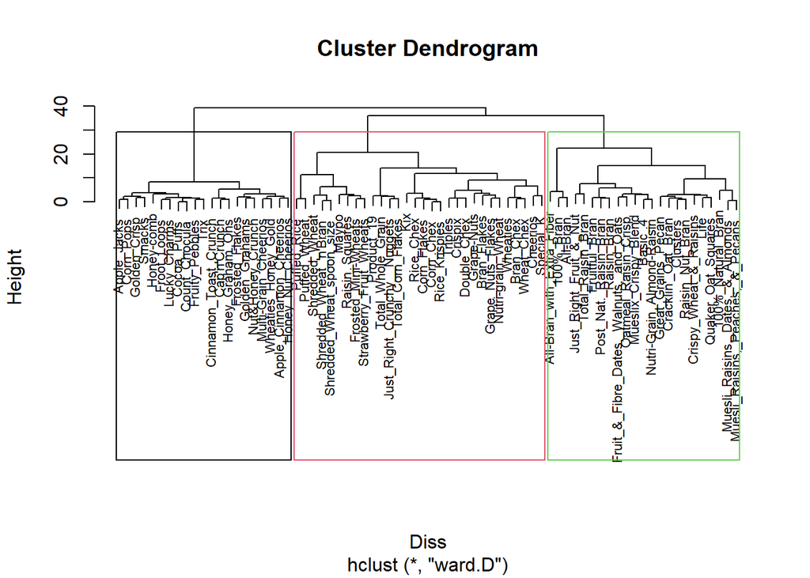

```r
Diss <-dist(Assign_New,method="euclidean")
hc_W<- hclust(Diss,method="ward.D")
plot(hc_W,cex=0.7)
rect.hclust(hc_W,k=3,border=1:3)
```

```r
cluster1<-cutree(hc_W,k=3)
dataframe2 <- as.data.frame(cbind(Assign_New,cluster1))
```

#The optimal number of clusters is 3 by the longest distance and the partition.

#Q3. Stability of clusters #Comment on the structure of the clusters and on their stability. Hint: To check stability,partition the data and see how well clusters formed based on one part apply to the other part. To do this:

● Cluster partition A

● Use the cluster centroids from A to assign each record in partition B (each record is assigned to the cluster with the closest centroid).

● Assess how consistent the cluster assignments are compared to the assignments based on all the data.

```r
set.seed(123)
kmeans_clust <- kmeans(Assign_New,3,nstart=10)
km_data <- kmeans_clust$cluster
cereal_cluster <- as.data.frame(cbind(kmeans_clust$cluster,Assign_New))
colnames(cereal_cluster)[1]<-"cluster"
print_clusters <-function(labels,k)
{
  for(i in 1:3)
  {
    print(paste("cluster", i))
    print(cereal_cluster[labels==i,c("cluster","calories" ,"protein" , "fat" ,     "sodium"  , "fiber"  , "carbo"  ,  "sugars"  , "potass"  , "vitamins" ,"shelf" ,   "weight"  , "cups"  ,   "rating"  )])

  }
}
groups <- cutree(hc_W, k=3)
print_clusters(groups,3)
```

```
## [1] "cluster 1"
##                                        cluster   calories    protein
## 100%_Bran                                    3 -1.8929836  1.3286071
## 100%_Natural_Bran                            1  0.6732089  0.4151897
## All-Bran                                     3 -1.8929836  1.3286071
## All-Bran_with_Extra_Fiber                    3 -2.9194605  1.3286071
## Basic_4                                      1  1.1864474  0.4151897
## Clusters                                     1  0.1599704  0.4151897
## Cracklin'_Oat_Bran                           1  0.1599704  0.4151897
## Crispy_Wheat_&_Raisins                       2 -0.3532681 -0.4982277
## Fruit_&_Fibre_Dates,_Walnuts,_and_Oats       1  0.6732089  0.4151897
## Fruitful_Bran                                1  0.6732089  0.4151897
## Great_Grains_Pecan                           1  0.6732089  0.4151897
## Just_Right_Fruit_&_Nut                       1  1.6996859  0.4151897
## Life                                         3 -0.3532681  1.3286071
## Muesli_Raisins,_Dates,_&_Almonds             1  2.2129244  1.3286071
## Muesli_Raisins,_Peaches,_&_Pecans            1  2.2129244  1.3286071
## Mueslix_Crispy_Blend                         1  2.7261629  0.4151897
## Nutri-Grain_Almond-Raisin                    1  1.6996859  0.4151897
## Oatmeal_Raisin_Crisp                         1  1.1864474  0.4151897
## Post_Nat._Raisin_Bran                        1  0.6732089  0.4151897
## Quaker_Oat_Squares                           3 -0.3532681  1.3286071
## Raisin_Bran                                  1  0.6732089  0.4151897
## Raisin_Nut_Bran                              1 -0.3532681  0.4151897
## Total_Raisin_Bran                            1  1.6996859  0.4151897
##                                                fat       sodium       fiber
## 100%_Bran                              -0.01290349 -0.353984399  3.29284661
## 100%_Natural_Bran                       3.96137277 -1.725770770 -0.06375361
## All-Bran                               -0.01290349  1.196730628  2.87327158
## All-Bran_with_Extra_Fiber              -1.00647256 -0.234698628  4.97114672
## Basic_4                                 0.98066557  0.600301771 -0.06375361
## Clusters                                0.98066557 -0.234698628 -0.06375361
## Cracklin'_Oat_Bran                      1.97423464 -0.234698628  0.77539645
## Crispy_Wheat_&_Raisins                 -0.01290349 -0.234698628 -0.06375361
## Fruit_&_Fibre_Dates,_Walnuts,_and_Oats  0.98066557  0.003872915  1.19497147
## Fruitful_Bran                          -1.00647256  0.958159085  1.19497147
## Great_Grains_Pecan                      1.97423464 -1.010056142  0.35582142
## Just_Right_Fruit_&_Nut                 -0.01290349  0.123158686 -0.06375361
## Life                                    0.98066557 -0.115412857 -0.06375361
## Muesli_Raisins,_Dates,_&_Almonds        1.97423464 -0.771484599  0.35582142
```

[output cut: 258 more lines]

```
## Puffed_Rice                  0.76901001  1.28782197
## Puffed_Wheat                 0.76901001  1.44796198
## Raisin_Squares              -1.37953029  0.90177096
## Rice_Chex                    1.32763048 -0.04746624
## Rice_Krispies                0.76901001 -0.14988985
## Shredded_Wheat               0.76901001  1.82029290
## Shredded_Wheat_'n'Bran      -0.64902659  2.26429773
## Shredded_Wheat_spoon_size   -0.64902659  2.14533086
## Special_K                    0.76901001  0.74502768
## Strawberry_Fruit_Wheats      0.76901001  1.18871964
## Total_Corn_Flakes            0.76901001 -0.27236281
## Total_Whole_Grain            0.76901001  0.28426404
## Triples                     -0.30526014 -0.25339630
## Wheat_Chex                  -0.64902659  0.50698324
## Wheaties                     0.76901001  0.63545985
```

```r
kbest.p<- 3
cboot.hclust <- clusterboot(Assign_New,clustermethod=hclustCBI,method="ward.D", k=kbest.p)
```

[output not shown]

[output cut: 45 more lines]

[output not shown]

```r
groups<-cboot.hclust$result$partition
cboot.hclust$bootmean
```

```
## [1] 0.6660267 0.6807289 0.8411100
```

```r
which.max(cboot.hclust$bootmean)
```

```
## [1] 3
```

#Cluster 3 has highest stability(cluster stability) amongst all. # or #It could also be done in the following way

#Creating Partitions

```r
Partion_1 <- Assign_New[1:50,]
Partion_2 <- Assign_New[51:74,]
```

#Performing Hierarchial Clustering, plotting dendogram and then cutting the dendogram by taking k = 3 .

```r
ag_single <- agnes(scale(Partion_1), method = "single")
ag_complete <- agnes(scale(Partion_1), method = "complete")
ag_average <- agnes(scale(Partion_1), method = "average")
ag_ward <- agnes(scale(Partion_1), method = "ward")

cbind(single=ag_single$ac , complete=ag_complete$ac , average= ag_average$ac , ward= ag_ward$ac)
```

```
##         single  complete   average      ward
## [1,] 0.6393338 0.8138238 0.7408904 0.8764323
```

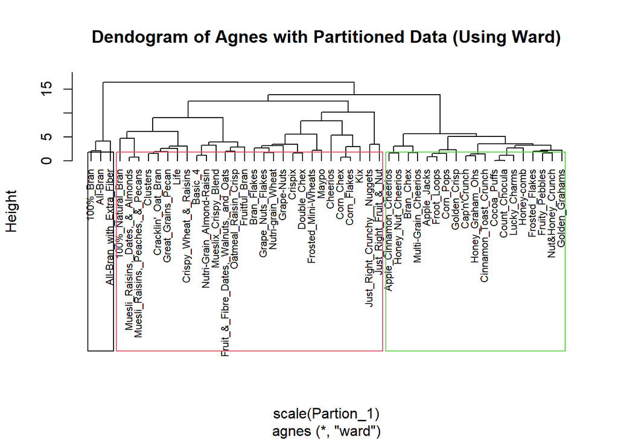

```r
pltree(ag_ward, cex = 0.7, hang = -1, main = "Dendogram of Agnes with Partitioned Data (Using Ward)")
rect.hclust(ag_ward, k = 3, border = 1:3)
```

```r
cut_2 <- cutree(ag_ward, k = 3)
```

#Calculating the centeroids.

```r
result <- as.data.frame(cbind(Partion_1, cut_2))
result[result$cut_2==1,]
```

```
##                            calories  protein         fat     sodium    fiber
## 100%_Bran                 -1.892984 1.328607 -0.01290349 -0.3539844 3.292847
## All-Bran                  -1.892984 1.328607 -0.01290349  1.1967306 2.873272
## All-Bran_with_Extra_Fiber -2.919461 1.328607 -1.00647256 -0.2346986 4.971147
##                               carbo     sugars   potass   vitamins     shelf
## 100%_Bran                 -2.508783 -0.2343906 2.575368 -0.1453172 0.9515734
## All-Bran                  -1.996924 -0.4627711 3.143464 -0.1453172 0.9515734
## All-Bran_with_Extra_Fiber -1.740994 -1.6046739 3.285488 -0.1453172 0.9515734
##                               weight      cups   rating cut_2
## 100%_Bran                 -0.1967771 -2.110034 1.832188     1
## All-Bran                  -0.1967771 -2.110034 1.193099     1
## All-Bran_with_Extra_Fiber -0.1967771 -1.379530 3.633385     1
```

```r
centroid_1 <- colMeans(result[result$cut_2==1,])
result[result$cut_2==2,]
```

```
##                                          calories    protein         fat
## 100%_Natural_Bran                       0.6732089  0.4151897  3.96137277
## Basic_4                                 1.1864474  0.4151897  0.98066557
## Bran_Flakes                            -0.8665066  0.4151897 -1.00647256
## Cheerios                                0.1599704  3.1554419  0.98066557
## Clusters                                0.1599704  0.4151897  0.98066557
## Corn_Chex                               0.1599704 -0.4982277 -1.00647256
## Corn_Flakes                            -0.3532681 -0.4982277 -1.00647256
## Cracklin'_Oat_Bran                      0.1599704  0.4151897  1.97423464
## Crispix                                 0.1599704 -0.4982277 -1.00647256
## Crispy_Wheat_&_Raisins                 -0.3532681 -0.4982277 -0.01290349
## Double_Chex                            -0.3532681 -0.4982277 -1.00647256
## Frosted_Mini-Wheats                    -0.3532681  0.4151897 -1.00647256
## Fruit_&_Fibre_Dates,_Walnuts,_and_Oats  0.6732089  0.4151897  0.98066557
## Fruitful_Bran                           0.6732089  0.4151897 -1.00647256
## Grape_Nuts_Flakes                      -0.3532681  0.4151897 -0.01290349
## Grape-Nuts                              0.1599704  0.4151897 -1.00647256
## Great_Grains_Pecan                      0.6732089  0.4151897  1.97423464
## Just_Right_Crunchy__Nuggets             0.1599704 -0.4982277 -0.01290349
## Just_Right_Fruit_&_Nut                  1.6996859  0.4151897 -0.01290349
## Kix                                     0.1599704 -0.4982277 -0.01290349
## Life                                   -0.3532681  1.3286071  0.98066557
## Maypo                                  -0.3532681  1.3286071 -0.01290349
## Muesli_Raisins,_Dates,_&_Almonds        2.2129244  1.3286071  1.97423464
## Muesli_Raisins,_Peaches,_&_Pecans       2.2129244  1.3286071  1.97423464
## Mueslix_Crispy_Blend                    2.7261629  0.4151897  0.98066557
## Nutri-Grain_Almond-Raisin               1.6996859  0.4151897  0.98066557
## Nutri-grain_Wheat                      -0.8665066  0.4151897 -1.00647256
## Oatmeal_Raisin_Crisp                    1.1864474  0.4151897  0.98066557
##                                              sodium       fiber       carbo
## 100%_Natural_Bran                      -1.725770770 -0.06375361 -1.74099432
## Basic_4                                 0.600301771 -0.06375361  0.81830100
## Bran_Flakes                             0.600301771  1.19497147 -0.46134666
## Cheerios                                1.554587942 -0.06375361  0.56237147
## Clusters                               -0.234698628 -0.06375361 -0.46134666
## Corn_Chex                               1.435302171 -0.90290366  1.84201913
## Corn_Flakes                             1.554587942 -0.48332864  1.58608960
## Cracklin'_Oat_Bran                     -0.234698628  0.77539645 -1.22913525
## Crispix                                 0.719587543 -0.48332864  1.58608960
## Crispy_Wheat_&_Raisins                 -0.234698628 -0.06375361 -0.97320572
```

[output cut: 90 more lines]

```
## Fruitful_Bran                          -0.11747555     2
## Grape_Nuts_Flakes                       0.66996501     2
## Grape-Nuts                              0.76209027     2
## Great_Grains_Pecan                      0.22395859     2
## Just_Right_Crunchy__Nuggets            -0.43723896     2
## Just_Right_Fruit_&_Nut                 -0.44095292     2
## Kix                                    -0.24379018     2
## Life                                    0.18952903     2
## Maypo                                   0.86744227     2
## Muesli_Raisins,_Dates,_&_Almonds       -0.39358784     2
## Muesli_Raisins,_Peaches,_&_Pecans      -0.60694559     2
## Mueslix_Crispy_Blend                   -0.87934079     2
## Nutri-Grain_Almond-Raisin              -0.14048156     2
## Nutri-grain_Wheat                       1.20857002     2
## Oatmeal_Raisin_Crisp                   -0.86955299     2
```

```r
centroid_2 <- colMeans(result[result$cut_2==2,])
result[result$cut_2==3,]
```

```
##                           calories    protein         fat     sodium
## Apple_Cinnamon_Cheerios  0.1599704 -0.4982277  0.98066557  0.2424445
## Apple_Jacks              0.1599704 -0.4982277 -1.00647256 -0.4136273
## Bran_Chex               -0.8665066 -0.4982277 -0.01290349  0.4810160
## Cap'n'Crunch             0.6732089 -1.4116451  0.98066557  0.7195875
## Cinnamon_Toast_Crunch    0.6732089 -1.4116451  1.97423464  0.6003018
## Cocoa_Puffs              0.1599704 -1.4116451 -0.01290349  0.2424445
## Corn_Pops                0.1599704 -1.4116451 -1.00647256 -0.8311275
## Count_Chocula            0.1599704 -1.4116451 -0.01290349  0.2424445
## Froot_Loops              0.1599704 -0.4982277 -0.01290349 -0.4136273
## Frosted_Flakes           0.1599704 -1.4116451 -1.00647256  0.4810160
## Fruity_Pebbles           0.1599704 -1.4116451 -0.01290349 -0.2943415
## Golden_Crisp            -0.3532681 -0.4982277 -1.00647256 -1.3679135
## Golden_Grahams           0.1599704 -1.4116451 -0.01290349  1.4353022
## Honey_Graham_Ohs         0.6732089 -1.4116451  0.98066557  0.7195875
## Honey_Nut_Cheerios       0.1599704  0.4151897 -0.01290349  1.0774449
## Honey-comb               0.1599704 -1.4116451 -1.00647256  0.2424445
## Lucky_Charms             0.1599704 -0.4982277 -0.01290349  0.2424445
## Multi-Grain_Cheerios    -0.3532681 -0.4982277 -0.01290349  0.7195875
## Nut&Honey_Crunch         0.6732089 -0.4982277 -0.01290349  0.3617302
##                               fiber       carbo     sugars     potass
## Apple_Cinnamon_Cheerios -0.27354112 -1.10117049  0.6791317 -0.4071355
## Apple_Jacks             -0.48332864 -0.97320572  1.5926539 -0.9752315
## Bran_Chex                0.77539645  0.05051241 -0.2343906  0.3739965
## Cap'n'Crunch            -0.90290366 -0.71727619  1.1358928 -0.9042195
## Cinnamon_Toast_Crunch   -0.90290366 -0.46134666  0.4507511 -0.7621955
## Cocoa_Puffs             -0.90290366 -0.71727619  1.3642734 -0.6201715
## Corn_Pops               -0.48332864 -0.46134666  1.1358928 -1.1172554
## Count_Chocula           -0.90290366 -0.71727619  1.3642734 -0.4781475
## Froot_Loops             -0.48332864 -0.97320572  1.3642734 -0.9752315
## Frosted_Flakes          -0.48332864 -0.20541712  0.9075122 -1.0462434
## Fruity_Pebbles          -0.90290366 -0.46134666  1.1358928 -1.0462434
## Golden_Crisp            -0.90290366 -0.97320572  1.8210345 -0.8332075
## Golden_Grahams          -0.90290366  0.05051241  0.4507511 -0.7621955
## Honey_Graham_Ohs        -0.48332864 -0.71727619  0.9075122 -0.7621955
## Honey_Nut_Cheerios      -0.27354112 -0.84524095  0.6791317 -0.1230875
## Honey-comb              -0.90290366 -0.20541712  0.9075122 -0.9042195
## Lucky_Charms            -0.90290366 -0.71727619  1.1358928 -0.6201715
## Multi-Grain_Cheerios    -0.06375361  0.05051241 -0.2343906 -0.1230875
## Nut&Honey_Crunch        -0.90290366  0.05051241  0.4507511 -0.8332075
```

[output cut: 25 more lines]

```
## Cinnamon_Toast_Crunch       3
## Cocoa_Puffs                 3
## Corn_Pops                   3
## Count_Chocula               3
## Froot_Loops                 3
## Frosted_Flakes              3
## Fruity_Pebbles              3
## Golden_Crisp                3
## Golden_Grahams              3
## Honey_Graham_Ohs            3
## Honey_Nut_Cheerios          3
## Honey-comb                  3
## Lucky_Charms                3
## Multi-Grain_Cheerios        3
## Nut&Honey_Crunch            3
```

```r
centroid_3 <- colMeans(result[result$cut_2==3,])
result[result$cut_2==4,]
```

```
##  [1] calories protein  fat      sodium   fiber    carbo    sugars   potass
##  [9] vitamins shelf    weight   cups     rating   cut_2
## <0 rows> (or 0-length row.names)
```

```r
centroid_4 <- colMeans(result[result$cut_2==4,])
centroids <- rbind(centroid_1, centroid_2, centroid_3, centroid_4)
x2 <- as.data.frame(rbind(centroids[,-14], Partion_2))
```

#Calculating the Distance

```r
Distance_1 <- get_dist(x2)
Matrix_1 <- as.matrix(Distance_1)
dataframe1 <- data.frame(data=seq(1,nrow(Partion_2),1), Clusters = rep(0,nrow(Partion_2)))
for(i in 1:nrow(Partion_2))
  {dataframe1[i,2] <- which.min(Matrix_1[i+4, 1:4])}
dataframe1
```

```
##    data Clusters
## 1     1        2
## 2     2        2
## 3     3        3
## 4     4        3
## 5     5        2
## 6     6        2
## 7     7        2
## 8     8        2
## 9     9        3
## 10   10        3
## 11   11        2
## 12   12        2
## 13   13        2
## 14   14        3
## 15   15        2
## 16   16        2
## 17   17        2
## 18   18        2
## 19   19        2
## 20   20        2
## 21   21        3
## 22   22        2
## 23   23        2
## 24   24        3
```

```r
cbind(dataframe2$Cluster1[51:74], dataframe1$Clusters)
```

```
##       [,1]
##  [1,]    2
##  [2,]    2
##  [3,]    3
##  [4,]    3
##  [5,]    2
##  [6,]    2
##  [7,]    2
##  [8,]    2
##  [9,]    3
## [10,]    3
## [11,]    2
## [12,]    2
## [13,]    2
## [14,]    3
## [15,]    2
## [16,]    2
## [17,]    2
## [18,]    2
## [19,]    2
## [20,]    2
## [21,]    3
## [22,]    2
## [23,]    2
## [24,]    3
```

```r
table(dataframe2$Cluster1[51:74] == dataframe1$Clusters)
```

```
## < table of extent 0 >
```

#Q4 Cluster with healthy Cereal and High nutrition value #The elementary public schools would like to choose a set of cereals to include in their daily cafeterias. Every day a different cereal is offered, but all cereals should support a healthy diet. For this goal, you are requested to find a cluster of “healthy cereals.”Should the data be normalized? If not, how should they be used in the cluster analysis?

```r
mydata <- na.omit(Assign_New)
rating <- cbind(mydata,cluster1)
rating[rating$clust==1,]
```

```
##                                          calories    protein         fat
## 100%_Bran                              -1.8929836  1.3286071 -0.01290349
## 100%_Natural_Bran                       0.6732089  0.4151897  3.96137277
## All-Bran                               -1.8929836  1.3286071 -0.01290349
## All-Bran_with_Extra_Fiber              -2.9194605  1.3286071 -1.00647256
## Basic_4                                 1.1864474  0.4151897  0.98066557
## Clusters                                0.1599704  0.4151897  0.98066557
## Cracklin'_Oat_Bran                      0.1599704  0.4151897  1.97423464
## Crispy_Wheat_&_Raisins                 -0.3532681 -0.4982277 -0.01290349
## Fruit_&_Fibre_Dates,_Walnuts,_and_Oats  0.6732089  0.4151897  0.98066557
## Fruitful_Bran                           0.6732089  0.4151897 -1.00647256
## Great_Grains_Pecan                      0.6732089  0.4151897  1.97423464
## Just_Right_Fruit_&_Nut                  1.6996859  0.4151897 -0.01290349
## Life                                   -0.3532681  1.3286071  0.98066557
## Muesli_Raisins,_Dates,_&_Almonds        2.2129244  1.3286071  1.97423464
## Muesli_Raisins,_Peaches,_&_Pecans       2.2129244  1.3286071  1.97423464
## Mueslix_Crispy_Blend                    2.7261629  0.4151897  0.98066557
## Nutri-Grain_Almond-Raisin               1.6996859  0.4151897  0.98066557
## Oatmeal_Raisin_Crisp                    1.1864474  0.4151897  0.98066557
## Post_Nat._Raisin_Bran                   0.6732089  0.4151897 -0.01290349
## Quaker_Oat_Squares                     -0.3532681  1.3286071 -0.01290349
## Raisin_Bran                             0.6732089  0.4151897 -0.01290349
## Raisin_Nut_Bran                        -0.3532681  0.4151897  0.98066557
## Total_Raisin_Bran                       1.6996859  0.4151897 -0.01290349
##                                              sodium       fiber       carbo
## 100%_Bran                              -0.353984399  3.29284661 -2.50878291
## 100%_Natural_Bran                      -1.725770770 -0.06375361 -1.74099432
## All-Bran                                1.196730628  2.87327158 -1.99692385
## All-Bran_with_Extra_Fiber              -0.234698628  4.97114672 -1.74099432
## Basic_4                                 0.600301771 -0.06375361  0.81830100
## Clusters                               -0.234698628 -0.06375361 -0.46134666
## Cracklin'_Oat_Bran                     -0.234698628  0.77539645 -1.22913525
## Crispy_Wheat_&_Raisins                 -0.234698628 -0.06375361 -0.97320572
## Fruit_&_Fibre_Dates,_Walnuts,_and_Oats  0.003872915  1.19497147 -0.71727619
## Fruitful_Bran                           0.958159085  1.19497147 -0.20541712
## Great_Grains_Pecan                     -1.010056142  0.35582142 -0.46134666
## Just_Right_Fruit_&_Nut                  0.123158686 -0.06375361  1.33016007
## Life                                   -0.115412857 -0.06375361 -0.71727619
## Muesli_Raisins,_Dates,_&_Almonds       -0.771484599  0.35582142  0.30644194
## Muesli_Raisins,_Peaches,_&_Pecans      -0.115412857  0.35582142  0.30644194
```

[output cut: 65 more lines]

```
## Fruit_&_Fibre_Dates,_Walnuts,_and_Oats -0.1244837        1
## Fruitful_Bran                          -0.1174756        1
## Great_Grains_Pecan                      0.2239586        1
## Just_Right_Fruit_&_Nut                 -0.4409529        1
## Life                                    0.1895290        1
## Muesli_Raisins,_Dates,_&_Almonds       -0.3935878        1
## Muesli_Raisins,_Peaches,_&_Pecans      -0.6069456        1
## Mueslix_Crispy_Blend                   -0.8793408        1
## Nutri-Grain_Almond-Raisin              -0.1404816        1
## Oatmeal_Raisin_Crisp                   -0.8695530        1
## Post_Nat._Raisin_Bran                  -0.3434906        1
## Quaker_Oat_Squares                      0.4873659        1
## Raisin_Bran                            -0.2425029        1
## Raisin_Nut_Bran                        -0.2108809        1
## Total_Raisin_Bran                      -1.0018246        1
```

```r
rating[rating$clust==2,]
```

```
##                           calories    protein         fat     sodium
## Apple_Cinnamon_Cheerios  0.1599704 -0.4982277  0.98066557  0.2424445
## Apple_Jacks              0.1599704 -0.4982277 -1.00647256 -0.4136273
## Cap'n'Crunch             0.6732089 -1.4116451  0.98066557  0.7195875
## Cinnamon_Toast_Crunch    0.6732089 -1.4116451  1.97423464  0.6003018
## Cocoa_Puffs              0.1599704 -1.4116451 -0.01290349  0.2424445
## Corn_Pops                0.1599704 -1.4116451 -1.00647256 -0.8311275
## Count_Chocula            0.1599704 -1.4116451 -0.01290349  0.2424445
## Froot_Loops              0.1599704 -0.4982277 -0.01290349 -0.4136273
## Frosted_Flakes           0.1599704 -1.4116451 -1.00647256  0.4810160
## Fruity_Pebbles           0.1599704 -1.4116451 -0.01290349 -0.2943415
## Golden_Crisp            -0.3532681 -0.4982277 -1.00647256 -1.3679135
## Golden_Grahams           0.1599704 -1.4116451 -0.01290349  1.4353022
## Honey_Graham_Ohs         0.6732089 -1.4116451  0.98066557  0.7195875
## Honey_Nut_Cheerios       0.1599704  0.4151897 -0.01290349  1.0774449
## Honey-comb               0.1599704 -1.4116451 -1.00647256  0.2424445
## Lucky_Charms             0.1599704 -0.4982277 -0.01290349  0.2424445
## Multi-Grain_Cheerios    -0.3532681 -0.4982277 -0.01290349  0.7195875
## Nut&Honey_Crunch         0.6732089 -0.4982277 -0.01290349  0.3617302
## Smacks                   0.1599704 -0.4982277 -0.01290349 -1.0696990
## Trix                     0.1599704 -1.4116451 -0.01290349 -0.2346986
## Wheaties_Honey_Gold      0.1599704 -0.4982277 -0.01290349  0.4810160
##                               fiber       carbo     sugars     potass
## Apple_Cinnamon_Cheerios -0.27354112 -1.10117049  0.6791317 -0.4071355
## Apple_Jacks             -0.48332864 -0.97320572  1.5926539 -0.9752315
## Cap'n'Crunch            -0.90290366 -0.71727619  1.1358928 -0.9042195
## Cinnamon_Toast_Crunch   -0.90290366 -0.46134666  0.4507511 -0.7621955
## Cocoa_Puffs             -0.90290366 -0.71727619  1.3642734 -0.6201715
## Corn_Pops               -0.48332864 -0.46134666  1.1358928 -1.1172554
## Count_Chocula           -0.90290366 -0.71727619  1.3642734 -0.4781475
## Froot_Loops             -0.48332864 -0.97320572  1.3642734 -0.9752315
## Frosted_Flakes          -0.48332864 -0.20541712  0.9075122 -1.0462434
## Fruity_Pebbles          -0.90290366 -0.46134666  1.1358928 -1.0462434
## Golden_Crisp            -0.90290366 -0.97320572  1.8210345 -0.8332075
## Golden_Grahams          -0.90290366  0.05051241  0.4507511 -0.7621955
## Honey_Graham_Ohs        -0.48332864 -0.71727619  0.9075122 -0.7621955
## Honey_Nut_Cheerios      -0.27354112 -0.84524095  0.6791317 -0.1230875
## Honey-comb              -0.90290366 -0.20541712  0.9075122 -0.9042195
## Lucky_Charms            -0.90290366 -0.71727619  1.1358928 -0.6201715
## Multi-Grain_Cheerios    -0.06375361  0.05051241 -0.2343906 -0.1230875
```

[output cut: 33 more lines]

```
## Count_Chocula                  2
## Froot_Loops                    2
## Frosted_Flakes                 2
## Fruity_Pebbles                 2
## Golden_Crisp                   2
## Golden_Grahams                 2
## Honey_Graham_Ohs               2
## Honey_Nut_Cheerios             2
## Honey-comb                     2
## Lucky_Charms                   2
## Multi-Grain_Cheerios           2
## Nut&Honey_Crunch               2
## Smacks                         2
## Trix                           2
## Wheaties_Honey_Gold            2
```

```r
rating[rating$clust==3,]
```

```
##                               calories    protein         fat     sodium
## Bran_Chex                   -0.8665066 -0.4982277 -0.01290349  0.4810160
## Bran_Flakes                 -0.8665066  0.4151897 -1.00647256  0.6003018
## Cheerios                     0.1599704  3.1554419  0.98066557  1.5545879
## Corn_Chex                    0.1599704 -0.4982277 -1.00647256  1.4353022
## Corn_Flakes                 -0.3532681 -0.4982277 -1.00647256  1.5545879
## Crispix                      0.1599704 -0.4982277 -1.00647256  0.7195875
## Double_Chex                 -0.3532681 -0.4982277 -1.00647256  0.3617302
## Frosted_Mini-Wheats         -0.3532681  0.4151897 -1.00647256 -1.9046994
## Grape_Nuts_Flakes           -0.3532681  0.4151897 -0.01290349 -0.2346986
## Grape-Nuts                   0.1599704  0.4151897 -1.00647256  0.1231587
## Just_Right_Crunchy__Nuggets  0.1599704 -0.4982277 -0.01290349  0.1231587
## Kix                          0.1599704 -0.4982277 -0.01290349  1.1967306
## Maypo                       -0.3532681  1.3286071 -0.01290349 -1.9046994
## Nutri-grain_Wheat           -0.8665066  0.4151897 -1.00647256  0.1231587
## Product_19                  -0.3532681  0.4151897 -1.00647256  1.9124453
## Puffed_Rice                 -2.9194605 -1.4116451 -1.00647256 -1.9046994
## Puffed_Wheat                -2.9194605 -0.4982277 -1.00647256 -1.9046994
## Raisin_Squares              -0.8665066 -0.4982277 -1.00647256 -1.9046994
## Rice_Chex                    0.1599704 -1.4116451 -1.00647256  0.9581591
## Rice_Krispies                0.1599704 -0.4982277 -1.00647256  1.5545879
## Shredded_Wheat              -1.3797451 -0.4982277 -1.00647256 -1.9046994
## Shredded_Wheat_'n'Bran      -0.8665066  0.4151897 -1.00647256 -1.9046994
## Shredded_Wheat_spoon_size   -0.8665066  0.4151897 -1.00647256 -1.9046994
## Special_K                    0.1599704  3.1554419 -1.00647256  0.8388733
## Strawberry_Fruit_Wheats     -0.8665066 -0.4982277 -1.00647256 -1.7257708
## Total_Corn_Flakes            0.1599704 -0.4982277 -0.01290349  0.4810160
## Total_Whole_Grain           -0.3532681  0.4151897 -0.01290349  0.4810160
## Triples                      0.1599704 -0.4982277 -0.01290349  1.0774449
## Wheat_Chex                  -0.3532681  0.4151897 -0.01290349  0.8388733
## Wheaties                    -0.3532681  0.4151897 -0.01290349  0.4810160
##                                   fiber       carbo       sugars      potass
## Bran_Chex                    0.77539645  0.05051241 -0.234390576  0.37399653
## Bran_Flakes                  1.19497147 -0.46134666 -0.462771138  1.29715251
## Cheerios                    -0.06375361  0.56237147 -1.376293384  0.08994853
## Corn_Chex                   -0.90290366  1.84201913 -0.919532261 -1.04624345
## Corn_Flakes                 -0.48332864  1.58608960 -1.147912823 -0.90421945
## Crispix                     -0.48332864  1.58608960 -0.919532261 -0.97523145
## Double_Chex                 -0.48332864  0.81830100 -0.462771138 -0.26511146
## Frosted_Mini-Wheats          0.35582142 -0.20541712 -0.006010015  0.01893653
```

[output cut: 69 more lines]

```
## Puffed_Rice                  1.28782197        3
## Puffed_Wheat                 1.44796198        3
## Raisin_Squares               0.90177096        3
## Rice_Chex                   -0.04746624        3
## Rice_Krispies               -0.14988985        3
## Shredded_Wheat               1.82029290        3
## Shredded_Wheat_'n'Bran       2.26429773        3
## Shredded_Wheat_spoon_size    2.14533086        3
## Special_K                    0.74502768        3
## Strawberry_Fruit_Wheats      1.18871964        3
## Total_Corn_Flakes           -0.27236281        3
## Total_Whole_Grain            0.28426404        3
## Triples                     -0.25339630        3
## Wheat_Chex                   0.50698324        3
## Wheaties                     0.63545985        3
```

#Mean ratings to determine the best cluster.

```r
mean(rating[rating$cluster1==1,"rating"])
```

```
## [1] 0.01688218
```

```r
mean(rating[rating$cluster1==2,"rating"])
```

```
## [1] -0.9836387
```

```r
mean(rating[rating$cluster1==3,"rating"])
```

```
## [1] 0.6239928
```

#As we can see that the mean ratings of the cluster3 is the highest, but as we are taking in consideration the word heathy diet which should include a cluster with healthy cereals I will choose cluster1 because of the following reason:

#Cluster 1 has high protein and fibre content compared to others.Hence, it can be said that cluster 1 possess high nutritional value and has healthy cereals

#Cluster 1 consists of fruits, nuts, wheat which can be considered as a healthy cereal.

#Data normalization is really important as we are using distance as a measure of performance.